# UPHL TP results by Calibration Range

T.Hooker

8 March, 2018

```r
#packge.set <- c("knitr", "rmarkdown", "plyr", "openxlsx", "lubridate", "htmlTable",
#                "reshape2", "tidyr", "formatR", "xtable", "dplyr")
#lapply(packge.set, library, character.only=T)
#options(table_counter=FALSE)
options(scipen = 999, digits = 4)
#opts_chunk$set(tidy=TRUE)
##
#startwork.date <- format(Sys.Date(), "%y%m%d")
```

### Notes

A meeting w/ UPHL in early 2018 revealed some potential inefficiencies in the analysis of Total Phosphorus (TP), using UPHLs implementation of analytical method EPA 365.1 (molybdate absorbance). The apparent inefficiency can affect the time-requirements of UPHL staff to perform TP analyses and the costs to DWQ when samples must be re-run on a separate, lower calibration curve with a concomitant hardware change. After the initial run on the HI-CAL method, ~ 20% of samples need to be diluted and rerun, while ~ 50% of samples need to be rerun on the LO-CAL method

*Overview of UPHL TP Procedure*

1. Samples are prepared for acid-persulfate digest in sets of 70 per batch, plus 20 QC samples
2. After digest, samples (a sample run w/ appropriate calibration, blanks, and CCV samples) are run (Lachat 8700 ?) against a higher-calibration (HI-CAL), ranging from 0.01 to 1.0 mg P/L (10 to 1000 ppb). A check standard of 0.02 mg P/L is used. Lab- and Matrix-spikes are at 0.10 mg P/L (100 ppb)
3. For any results where the result value is < 0.02 mg P/L (20 ppb), the samples are rerun on the instrument after a change in hardware (manifold, flow lines) and calibration-standards
4. The lower-calibration (LO-CAL) ranges from 0.003 to 0.20 mg P/L (3 to 200 ppb)
5. The digest is approximately 8.2 mL of sample with 0.3 mL H<sup>+</sup> and 0.25 mL of K<sub>2</sub>SO<sub>4</sub>. [*These details can be confirmed by reviewing EPA 365.1*]

**Goal**

Examine whether significant / severe bias exists in results that lie in lower portions of the HI-CAL range, relative to re-run results using the LO-CAL setup

**Current Reporting Limits**

- Minimum Reporting Limit :: MRL = 0.003 mg P/L (3.0 $\mu$g P/L)
- Method Detection Level :: MDL = 0.00277 mg P/L (2.77 $\mu$g P/L)

**Objective**

**Data-report nomenclature**

LRB = lab reagent blank / aka Method-Blank  
LFB = lab fortified blank / *spiked* Method-Blank  
LFM = lab fortified matrix / *spiked* Sample

- For any duplicate records:
  - Use RV that has the oldest / most recent analysis datetime
  - Use RV w/ lowest position in file

Filename structure :: YYMMDD + [5/6] + {1:reps}.csv

- **5** (as 50, 51, etc) identifies HI-CAL
- **6** (as 60, 61, etc) identifies LO-CAL

### 1.0 Import Data

```r
#files <- choose.files(caption="Select DATA files [*.txt]", multi = TRUE)
b <- lapply(files, FUN=read.csv, header=TRUE, stringsAsFactors=F)
#
filename <- basename(files)
names(b) <- filename
path.filename <- dirname(files)
```

A total of 70 data files were selected from path: **K:/WQX/processed/Toby’s Phosphate Data**

```r
options(width=95)
file.list <- filename
length(file.list) <- prod(dim(matrix(file.list, ncol=5)))
filelist.dat <- data.frame(matrix(data=(file.list), ncol=5, byrow=TRUE))
htmlTable::htmlTable(filelist.dat, caption = "Names of imported data files", css.cell = rbind(rep("padding-left: 1em; padding-right: 1em;font-size: 0.8em;", times=ncol(filelist.dat)), matrix("padding-left: 0.8em; padding-right: 0.8em; font-size: 0.8em;", ncol=ncol(filelist.dat), nrow=nrow(filelist.dat))), align="l", header = rep(NA, times = ncol(filelist.dat)))
```

| Names of imported data files | Names of imported data files | Names of imported data files | Names of imported data files | Names of imported data files | Names of imported data files |
| --- | --- | --- | --- | --- | --- |
| 1 | 17072850.csv | 17072860.csv | 17080350.csv | 17080360.csv | 17080850.csv |
| 2 | 17080860.csv | 17080950.csv | 17080951.csv | 17080960.csv | 17081050.csv |
| 3 | 17081060.csv | 17081550.csv | 17081560.csv | 17081650.csv | 17081660.csv |
| 4 | 17082150.csv | 17082160.csv | 17082450.csv | 17082460.csv | 17082461.csv |
| 5 | 17082950.csv | 17082960.csv | 17083050.csv | 17083060.csv | 17091250.csv |
| 6 | 17091260.csv | 17091350.csv | 17091360.csv | 17091450.csv | 17091460.csv |
| 7 | 17092050.csv | 17092051.csv | 17092060.csv | 17092150.csv | 17092160.csv |
| 8 | 17092250.csv | 17092260.csv | 17092650.csv | 17092660.csv | 17092750.csv |
| 9 | 17092751.csv | 17092760.csv | 17092950.csv | 17092960.csv | 17100250.csv |
| 10 | 17100260.csv | 17100650.csv | 17100660.csv | 17101050.csv | 17101060.csv |
| 11 | 17101150.csv | 17101160.csv | 17101650.csv | 17101660.csv | 17101850.csv |
| 12 | 17101860.csv | 17102550.csv | 17102560.csv | 17102650.csv | 17102660.csv |
| 13 | 17102750.csv | 17102760.csv | 17103150.csv | 17103160.csv | 17110150.csv |
| 14 | 17110160.csv | 17110650.csv | 17110660.csv | 17110750.csv | 17110760.csv |

```r
rm(filelist.dat)
```

#### 1.1 Extract to Dataframe

```r
TP.dat0 <- plyr::ldply(b, .id="Lab.filename")
TP.dat0$Lab.filename <- as.character(TP.dat0$Lab.filename)
# addition record position
TP.dat0$posn <- NA
for (j in unique(TP.dat0$Lab.filename)){
    for (m in 1:nrow(TP.dat0[TP.dat0$Lab.filename == j,])) {
        TP.dat0$posn[TP.dat0$Lab.filename == j][m] <- m  }  }
```

**Examine dataframe**

```r
data.file <- TP.dat0 #
Data.Vars <- data.frame()
for (i in 1:length(names(data.file))) {
  class_i <- class(data.file[,i])
  name_i <- names(data.file[i])
  num.NAs <- sum(is.na(data.file[,i]))
  count_levels <- as.numeric(length(unique((data.file[,i]))))
  num.blanks <- length(data.file[as.character(data.file[,i]) == "",c(i)]) # fixed for dates
  num.Obs <- nrow(data.file)-num.blanks
Data.Vars <- rbind(Data.Vars, data.frame(i, name_i, class_i, num.NAs, count_levels, num.blanks, num.Obs)) }
#
htmlTable::htmlTable(Data.Vars, caption ="Datafile Characteristics of LAB DATA", align = c("l", "c"), css.cell = "padding-left: 1.5em; padding-right: 1.5em; font-size: 0.8em;", rnames = FALSE, header = c("Field No.", "Field Name", "Class","NAs", "Levels", "Blanks", "Obs"))
```

[output not shown]

#### 1.2 Cleanup Field-names

- Long field-names are *annoying*

```r
names(TP.dat0)[3] <- "Adate"
names(TP.dat0)[4] <- "Atime"
names(TP.dat0)[5] <- "DF"
names(TP.dat0)[6] <- "RV" # values are already adjusted for DF
names(TP.dat0)[7] <- "Units"
names(TP.dat0)[8] <- "Analyte"
```

- Clean Dates (to Dates)

```r
TP.dat0$Adate <- lubridate::mdy(TP.dat0$Adate)
# leave time alone for now
```

#### 1.3 Sample Keys

```r
TP.dat0$SKey1 <- paste(TP.dat0$Sample.ID, as.numeric(TP.dat0$Adate - as.Date("1899-12-30")), sep=".")
# CAL-type
TP.dat0$CAL.type <- ifelse(substr(TP.dat0$Lab.filename, 7,7) == 5,
                           "HiCAL",
                           ifelse(substr(TP.dat0$Lab.filename, 7,7) == 6,
                                  "LoCAL", NA))
# SKey2
TP.dat0$SKey2 <- paste(TP.dat0$SKey1, TP.dat0$CAL.type, sep=".")
```

### 2.0 Examine Data

- Re-arrange data to examine similar samples (as Sample.ID)

```r
TP.dat1 <- dplyr::arrange(TP.dat0, Sample.ID, Lab.filename, posn)
```

- Total number of unique `Sample.ID` (including CAL and QC-samples) :: 2,331

**Look at counts of sample.IDs**

```r
x0 <- as.data.frame(table(TP.dat1$Sample.ID, useNA = "ifany"))
table(x0$Freq)
```

```
   1    2    3   67  165  319  575  577
 875 1438    2   10    2    2    1    1
```

- May have up to ~ [1438] pairs of Lo x Hi-Cal samples

**Extract Result-pairs from `TP.dat1`**

```r
TP.sets <- as.character(sort(unique(x0$Var1[x0$Freq == 2])))
TP.pairs <- TP.dat1[TP.dat1$Sample.ID %in% TP.sets,]
```

**dCast `TP.pairs` by Analyte**

```r
library(reshape2)
TP.pairs_cast <- dcast(TP.pairs, Sample.ID ~ CAL.type,
                      value.var = "RV", mean)
TP.pairs_cast <- TP.pairs_cast[!is.na(TP.pairs_cast$LoCAL),]
```

**Results x Cal-Type Summary**

```r
summary(TP.pairs_cast$HiCAL)
```

```
     Min.   1st Qu.    Median      Mean   3rd Qu.      Max.
-0.006720  0.005410  0.007645  0.008554  0.011200  0.037700
```

```r
summary(TP.pairs_cast$LoCAL)
```

```
     Min.   1st Qu.    Median      Mean   3rd Qu.      Max.
-0.000156  0.005335  0.007765  0.008637  0.011400  0.040000
```

### 3.0 Compare Results

#### 3.1 Fig 1 :: Boxplots by Calibration Range

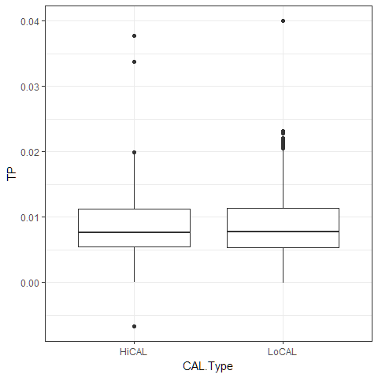

- No substantial signs of result-bias by calibration type [range]

#### 3.2 Compare paired results

```r
TP.pairs_cast$resid <- TP.pairs_cast$HiCAL - TP.pairs_cast$LoCAL
TP.pairs_cast$rpd_high <- round(as.numeric(TP.pairs_cast$resid / TP.pairs_cast$HiCAL)*100, digits = 2)
TP.pairs_cast$rpd_high.abs <- round(abs(as.numeric(TP.pairs_cast$resid / TP.pairs_cast$HiCAL)*100), digits = 2)
# class
TP.pairs_cast$GRP <- ifelse(TP.pairs_cast$rpd_high.abs > 30,
                            ifelse(abs(TP.pairs_cast$resid) > 0.003,
                                   "Hi_var", "ok"),
                            "ok")
```

#### 3.3 Fig 2 :: Scatterplot of Hi-Low calibration pairs

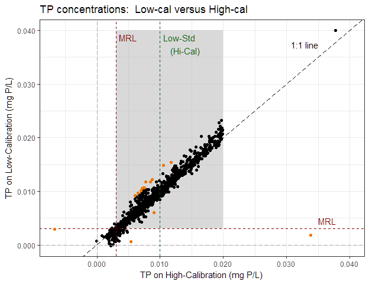

- The scatterplot above illustrates the reasonable low apparent-bias in TP concentrations below 0.020 mg P/KL (= 20 ppb P)

An additional plot, with a closer look at results near the current MRL is below…

#### 3.4 Fig 3 :: [Zoomed] Scatterplot

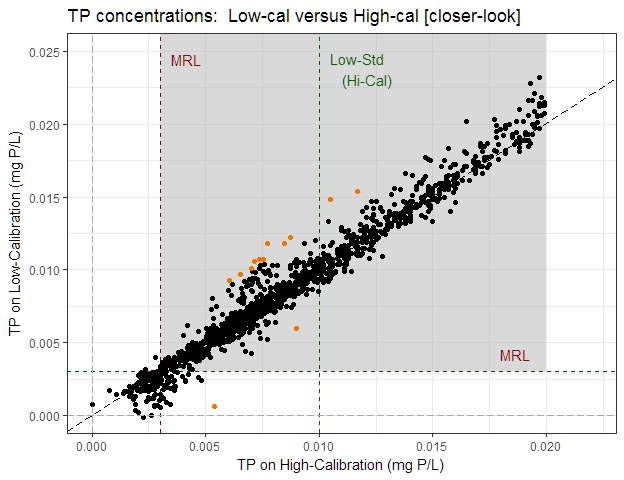

#### 3.45 Quick LM on plot

```r
TPmod.dat <- TP.pairs_cast[TP.pairs_cast$HiCAL <= 0.02,]

TPmod1.lm <- lm(LoCAL ~ HiCAL, data=TPmod.dat)
TPmod1.summ <- summary(TPmod1.lm)
TP1.seyx <- TPmod1.summ$sigma
#
TPmod.dat2 <- TP.pairs_cast[TP.pairs_cast$GRP == "ok" & TP.pairs_cast$HiCAL <= 0.02,]

TPmod2.lm <- lm(LoCAL ~ HiCAL, data=TPmod.dat2)
TPmod2.summ <- summary(TPmod2.lm)
TP2.seyx <- TPmod2.summ$sigma
```

- Let’s take a look at the *residuals* w/ the close-up scale…

#### 3.5 Fig 4 :: Residuals Plot

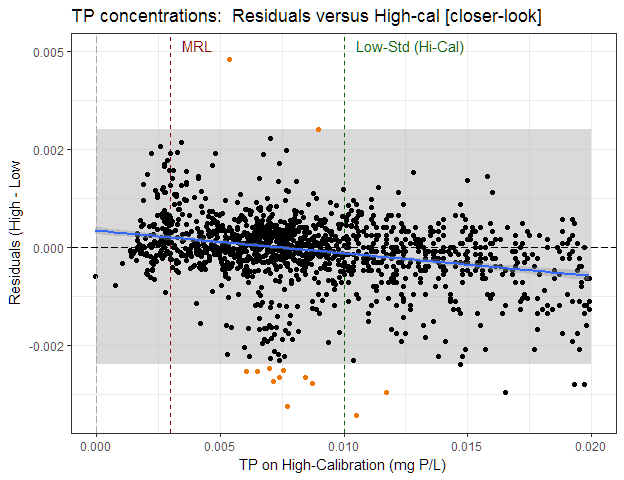

### 4.0 All TP results in AWQMS

#### 4.1 Import TP AWQMS file

Import result-summary-file for all TP analyses form AWQMS

```r
library(openxlsx)
filename.tp <- choose.files(caption="Select File to Import (XLSX)", multi=FALSE)
DATA.file <- read.xlsx(filename.tp, sheet=1, startRow = 1, colNames=TRUE, rowNames=FALSE)
TPall.dat <- DATA.file; rm(DATA.file)
```

Current file [**ResultListExport_180316.xlsx**], as of [04/12/2018] has:

- 103,791 records
- 4,279 unique sites
- Datafile created on :: 2018-03-16 13:44:07
- Datafile was last accessed :: 2018-04-10 12:06:23

#### 4.15 Fix Dates

```r
TPall.dat$Activity.Start.Date <- as.Date(TPall.dat$Activity.Start.Date, origin="1899-12-30")
```

#### 4.2 Import Monitoring Location ID file

Use MLID-file to subset `TPall.dat` for specific water body types

Path for Master-Geofile [MonLoc] (from AWQMS) :: + `L:\DATA MANAGEMENT & QA\DATA.Projects\GEOFILE_awqms_r`

```r
MLID.file <- choose.files(caption="Select _working_ DATA file [*.RData", multi = FALSE)
load(MLID.file)
```

Dataframe name is :: `MonLoc.file`

- Contains 7878 records / site.IDs

```r
library(tidyr)
tab01 <- as.data.frame.table(addmargins(table(MonLoc.file$Monitoring.Location.Type, useNA = "ifany"))) %>% dplyr::rename("MLID.Type" = "Var1", "nObs" = "Freq")
#
tab <- tab01
htmlTable::htmlTable(tab, caption = "Monitoring Location Types", css.cell = rbind(rep("padding-left: 1em; padding-right: 1em;font-size: 0.7em;", times=ncol(tab)), matrix("padding-left: 0.8em; padding-right: 0.8em; font-size: 0.9em;", ncol=ncol(tab), nrow=nrow(tab))), align="lc", total = TRUE, rnames=F)
```

| Monitoring Location Types MLID.Type | Monitoring Location Types nObs |
| --- | --- |
| Canal Drainage | 144 |
| Canal Irrigation | 63 |
| Canal Transport | 53 |
| Facility Industrial | 1 |
| Facility Other | 538 |
| Lake | 1178 |
| Mine/Mine Discharge | 12 |
| Ocean | 1 |
| Other-Ground Water | 15 |
| Reservoir | 2 |
| River/Stream | 3920 |
| Seep | 25 |
| Spring | 425 |
| Storm Sewer | 48 |
| Waste Sewer | 8 |
| Well | 1182 |
| Wetland Undifferentiated | 263 |
| Sum | 7878 |

```r
addmargins(table(MonLoc.file$Monitoring.Location.Type, MonLoc.file$QC_type, useNA = "ifany"))
```

```
                           Blank Replicate <NA>  Sum
  Canal Drainage               0         1  143  144
  Canal Irrigation             0         0   63   63
  Canal Transport              1         0   52   53
  Facility Industrial          0         0    1    1
  Facility Other               1         7  530  538
  Lake                         9        92 1077 1178
  Mine/Mine Discharge          0         0   12   12
  Ocean                        0         0    1    1
  Other-Ground Water           0         0   15   15
  Reservoir                    0         0    2    2
  River/Stream                85       105 3730 3920
  Seep                         0         0   25   25
  Spring                       0         1  424  425
  Storm Sewer                  0         0   48   48
  Waste Sewer                  0         0    8    8
  Well                         0         0 1182 1182
  Wetland Undifferentiated     5         5  253  263
  Sum                        101       211 7566 7878
```

#### 4.3 Join TP-data w/ MLID-info

```r
library(dplyr, quietly=TRUE)
TPall.dat2 <- left_join(TPall.dat, MonLoc.file[,c(3,6,52,53)],
                        by = "Monitoring.Location.ID")
```

```r
addmargins(table(TPall.dat2$Monitoring.Location.Type, TPall.dat2$QC_type, useNA = "ifany"))
```

```
                            Blank Replicate   <NA>    Sum
  Canal Drainage                0         1   1191   1192
  Canal Irrigation              0         0    126    126
  Canal Transport               0         0    843    843
  Facility Other                0        20   4970   4990
  Lake                        164       238  20988  21390
  Mine/Mine Discharge           0         0     10     10
  Other-Ground Water            0         0     36     36
  River/Stream                393      1121  66363  67877
  Seep                          0         0     26     26
  Spring                        0         0   1706   1706
  Storm Sewer                   0         0    442    442
  Waste Sewer                   0         0    127    127
  Well                          0         0   2544   2544
  Wetland Undifferentiated      6         1   1516   1523
  <NA>                          0         0    959    959
  Sum                         563      1381 101847 103791
```

```r
table(as.numeric(format(TPall.dat2$Activity.Start.Date, "%Y")), TPall.dat2$QC_type, useNA = "ifany")
```

```
       Blank Replicate <NA>
  1990     0        17 3301
  1991     0        20 3610
  1992     0         4 3691
  1993     0         0 4519
  1994     0         3 4223
  1995     0         2 4319
  1996     0         4 3914
  1997     0         6 1661
  1998     0        13 3950
  1999     0        18 4470
  2000     0        11 3432
  2001     0         9 4422
  2002     0        13 3787
  2003     0        12 4344
  2004     0        15 5257
  2005     0        22 4976
  2006     0        32 4831
  2007     0        26 3930
  2008     0        20 3864
  2009    55       109 4178
  2010     7        65 3414
  2011    82       136 3345
  2012    86       133 3121
  2013    75       144 2414
  2014   105       164 2935
  2015    73       177 2945
  2016    53       171 2670
  2017    27        35  324
```

#### 4.4 Plot eCDF of TP results

```r
library(ggplot2); library(scales); library(dplyr)
```

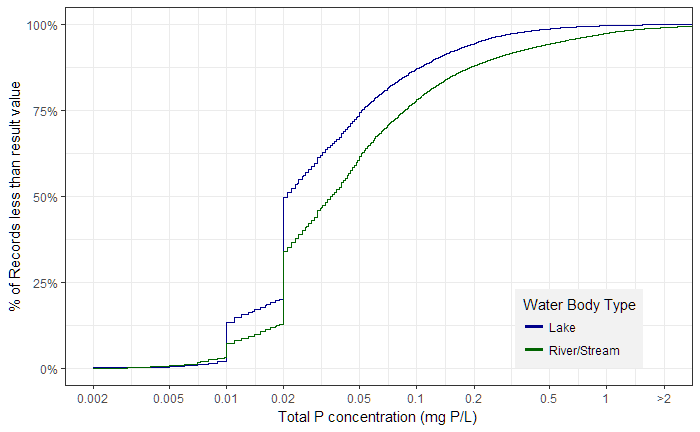

```r
fig01_data <- filter(TPall.dat2,
                     is.na(QC_type) & !is.na(Monitoring.Location.Type) &
        (Monitoring.Location.Type == "Lake" | Monitoring.Location.Type == "River/Stream"))
#
ggplot(data=fig01_data) + theme_bw() +
    stat_ecdf(aes(x=RV.x, col=Monitoring.Location.Type), na.rm=T, pad=F) +
    scale_x_continuous(limits=c(0.002, NA), trans = "log10",
                       breaks=c(0.002, 0.005, 0.010, 0.020, 0.05, 0.1, 0.2, 0.5, 1, 2),
                       labels=c(0.002, 0.005, 0.010, 0.020, 0.05, 0.1, 0.2, 0.5, 1, ">2"),
                       name="Total P concentration (mg P/L)", oob=squish) +
    coord_cartesian(xlim=c(0.002, 2)) +
    scale_y_continuous(labels = percent, name="% of Records less than result value") +
    guides(col = guide_legend(title = "Water Body Type", override.aes = list(size=1.2))) +
    scale_color_manual(values=c("darkblue", "darkgreen")) +
    theme(legend.position=c(0.82,0.15), legend.background = element_rect(fill="gray95"),
          legend.key = element_rect(fill="gray95"))
#
ggsave(paste("TPall_fig01_cdf_", format(Sys.Date(), "%y%m%d"), ".jpeg", sep=""),
       height=4, width=5, dpi=500)
```

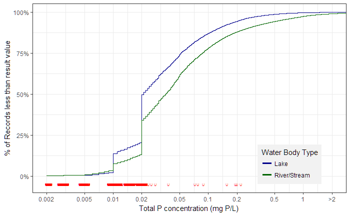

```r
ggplot(data=fig01_data) + theme_bw() +
    stat_ecdf(aes(x=RV.x, col=Monitoring.Location.Type), na.rm=T, pad=F) +
    scale_x_continuous(limits=c(0.002, NA), trans = "log10",
                       breaks=c(0.002, 0.005, 0.010, 0.020, 0.05, 0.1, 0.2, 0.5, 1, 2),
                       labels=c(0.002, 0.005, 0.010, 0.020, 0.05, 0.1, 0.2, 0.5, 1, ">2"),
                       name="Total P concentration (mg P/L)", oob=squish) +
    coord_cartesian(xlim=c(0.002, 2)) +
    scale_y_continuous(labels = percent, name="% of Records less than result value") +
    guides(col = guide_legend(title = "Water Body Type", override.aes = list(size=1.2))) +
    scale_color_manual(values=c("darkblue", "darkgreen")) +
    theme(legend.position=c(0.82,0.15), legend.background = element_rect(fill="gray95"),
          legend.key = element_rect(fill="gray95")) +
    geom_jitter(data=fig01_data[!is.na(fig01_data$Detection.Condition) & fig01_data$Detection.Condition == "Not Detected",], aes(x=RV.x, y = (-0.05)),
               shape="U", col="red", width=0.05, height=0)
#
ggsave(paste("TPall_fig02_cdf_", format(Sys.Date(), "%y%m%d"), ".jpeg", sep=""),
       height=4, width=5, dpi=500)
```

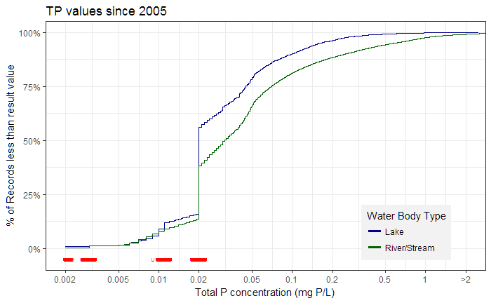

```r
fig03_data <- fig01_data[fig01_data$Activity.Start.Date > as.Date("2005-01-01"),]
#
ggplot(data=fig03_data[]) + theme_bw() +
    stat_ecdf(aes(x=RV.x, col=Monitoring.Location.Type), na.rm=T, pad=F) +
    scale_x_continuous(limits=c(0.002, NA), trans = "log10",
                       breaks=c(0.002, 0.005, 0.010, 0.020, 0.05, 0.1, 0.2, 0.5, 1, 2),
                       labels=c(0.002, 0.005, 0.010, 0.020, 0.05, 0.1, 0.2, 0.5, 1, ">2"),
                       name="Total P concentration (mg P/L)", oob=squish) +
    coord_cartesian(xlim=c(0.002, 2)) +
    scale_y_continuous(labels = percent, name="% of Records less than result value") +
    guides(col = guide_legend(title = "Water Body Type", override.aes = list(size=1.2))) +
    scale_color_manual(values=c("darkblue", "darkgreen")) +
    theme(legend.position=c(0.82,0.15), legend.background = element_rect(fill="gray95"),
          legend.key = element_rect(fill="gray95")) +
    geom_jitter(data=fig03_data[!is.na(fig03_data$Detection.Condition) & fig03_data$Detection.Condition == "Not Detected",], aes(x=RV.x, y = (-0.05)),
               shape="U", col="red", width=0.05, height=0) +
    ggtitle("TP values since 2005")
#
ggsave(paste("TPall_fig03_cdf_", format(Sys.Date(), "%y%m%d"), ".jpeg", sep=""),
       height=4, width=5, dpi=500)
```

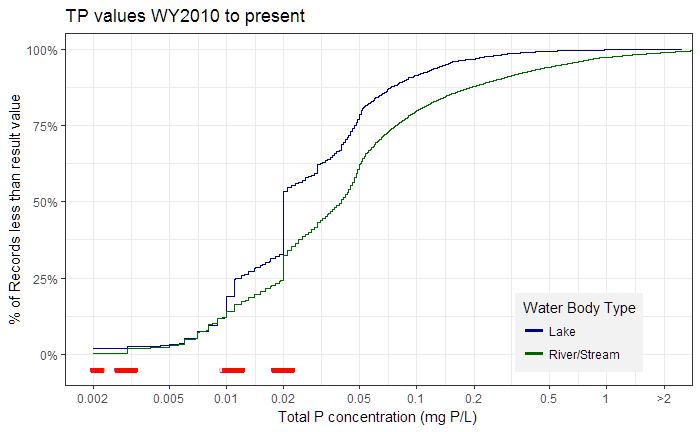

```r
fig04_data <- fig03_data[fig03_data$Activity.Start.Date > as.Date("2009-09-30"),]
#
library(ggplot2); library(scales)
ggplot(data=fig04_data[]) + theme_bw() +
    stat_ecdf(aes(x=RV.x, col=Monitoring.Location.Type), na.rm=T, pad=F) +
    scale_x_continuous(limits=c(0.002, NA), trans = "log10",
                       breaks=c(0.002, 0.005, 0.010, 0.020, 0.05, 0.1, 0.2, 0.5, 1, 2),
                       labels=c(0.002, 0.005, 0.010, 0.020, 0.05, 0.1, 0.2, 0.5, 1, ">2"),
                       name="Total P concentration (mg P/L)", oob=squish) +
    coord_cartesian(xlim=c(0.002, 2)) +
    scale_y_continuous(labels = percent, name="% of Records less than result value") +
    guides(col = guide_legend(title = "Water Body Type", override.aes = list(size=1.2))) +
    scale_color_manual(values=c("darkblue", "darkgreen")) +
    theme(legend.position=c(0.82,0.15), legend.background = element_rect(fill="gray95"),
          legend.key = element_rect(fill="gray95")) +
    geom_jitter(data=fig04_data[!is.na(fig04_data$Detection.Condition) & fig04_data$Detection.Condition == "Not Detected",], aes(x=RV.x, y = (-0.05)),
               shape="U", col="red", width=0.05, height=0, na.rm=T) +
    ggtitle("TP values WY2010 to present")
#
ggsave(paste("TPall_fig04_cdf_", format(Sys.Date(), "%y%m%d"), ".jpeg", sep=""),
       height=4, width=5, dpi=500)
```

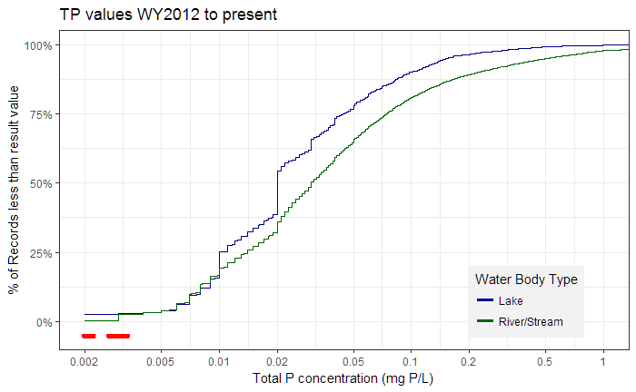

```r
fig04_data <- fig03_data[fig03_data$Activity.Start.Date > as.Date("2011-09-30"),]
#
library(ggplot2); library(scales)
ggplot(data=fig04_data[]) + theme_bw() +
    stat_ecdf(aes(x=RV.x, col=Monitoring.Location.Type), na.rm=T, pad=F) +
    scale_x_continuous(limits=c(0.002, NA), trans = "log10",
                       breaks=c(0.002, 0.005, 0.010, 0.020, 0.05, 0.1, 0.2, 0.5, 1, 2),
                       labels=c(0.002, 0.005, 0.010, 0.020, 0.05, 0.1, 0.2, 0.5, 1, ">2"),
                       name="Total P concentration (mg P/L)", oob=squish) +
    coord_cartesian(xlim=c(0.002, 1)) +
    scale_y_continuous(labels = percent, name="% of Records less than result value") +
    guides(col = guide_legend(title = "Water Body Type", override.aes = list(size=1.2))) +
    scale_color_manual(values=c("darkblue", "darkgreen")) +
    theme(legend.position=c(0.82,0.15), legend.background = element_rect(fill="gray95"),
          legend.key = element_rect(fill="gray95")) +
    geom_jitter(data=fig04_data[!is.na(fig04_data$Detection.Condition) & fig04_data$Detection.Condition == "Not Detected",], aes(x=RV.x, y = (-0.05)),
               shape="U", col="red", width=0.05, height=0, na.rm=T) +
    ggtitle("TP values WY2012 to present")
#
ggsave(paste("TPall_fig05_cdf_", format(Sys.Date(), "%y%m%d"), ".jpeg", sep=""),
       height=4, width=5, dpi=500)
```

### 5.0 Other data-questions

#### 5.1 How many high-samples?

DF == `TP.dat1`

- Total number of records in UPHL-dataset run on HiCAL :: 4068
- Number of unique SKeys :: 2842
  - *many of these are lab-QC samples…*

```r
HiCAL <- TP.dat1[TP.dat1$CAL.type == "HiCAL",]
HiC.uniq <- HiCAL$SKey2[duplicated(HiCAL$SKey2)]
HiCAL$dupe_rec <- ifelse(HiCAL$SKey2 %in% HiC.uniq,"dupe", NA)
#
HiCAL$SampType <- ifelse(is.na(as.integer(HiCAL$Sample.ID)), "QC", "samp")
table(HiCAL$SampType, useNA = "ifany")
```

- Records in HiCAL for “samples” :: 2366
- Number of unique *Sample* keys :: 2314
  - Number of unique *Sample* keys w/ duplicate-records :: 50

### Wrap Up

**Start work date ::** 180308  
**Last work date ::** 180309  
**Current work / review date ::** 180412

eof